# NHANES Part I

Tam Nguyen

## Quantitative Response, Quantitative Predictors: MULTIPLE LINEAR REGRESSION

ORIGINAL SOURCE: National Health and Nutrition Examination Survey, Centers for Disease Control and Prevention, http://www.cdc.gov/nchs/nhanes.htm.

Usually, body weight is determined by weighing on a scale. But what if a scale is unavailable? Could body weight be estimated using other, more easily measured, body measurements? Suppose we only have a tape measure available, so we can only consider the body measurements obtained using a tape measure. We would like to model weight as a linear (we hope!) function of length and circumference measurements, following “Occam’s razor” or the “law of parsimony”, which says “entities should not be multiplied beyond necessity” or “Of two equivalent theories or explanations, all other things being equal, the simpler one is to be preferred.”

That is, we would like to have an “estimating equation” for body weight that provides the “best” estimate *with the fewest variables*.

We will be using data from NHANES 2009-2010 data to model body weight as a linear function of arm circumference and arm length. We will restrict attention to only those individuals who are between 18 and 24 years old (inclusive). That is, we will restrict attention to “young adults”.

**Variables:**

Y: body weight in kg

X1: upper arm circumference in cm

X2: upper arm length in cm

**Data set**: on Moodle as “NHANES-body.csv”. Download the file, then load it into the Console, then cut-and-paste the `read_csv` code into the chunk below.

Load data set (call it `nhanes`) and the mosiac package here:

## A. Investigating the Data

1. You can read about the NHANES survey in the NHANES brochure (on the Moodle page). From the information provided, do you feel the ever-present assumptions of representativeness and independence are satisfied with this data? Why or why not?
- NHANES use complex survey designs that oversample certain subpopulations like racial minorities. Naïve analysis of the original NHANES data can lead to mistaken conclusions. The percentages of people from each racial group in the data, for example, are quite different from the way they are in the population.
2. **Univariate Distributions:** Using graphical and descriptive statistics, describe the main features of the distribution of each variable, noting any unusual features.

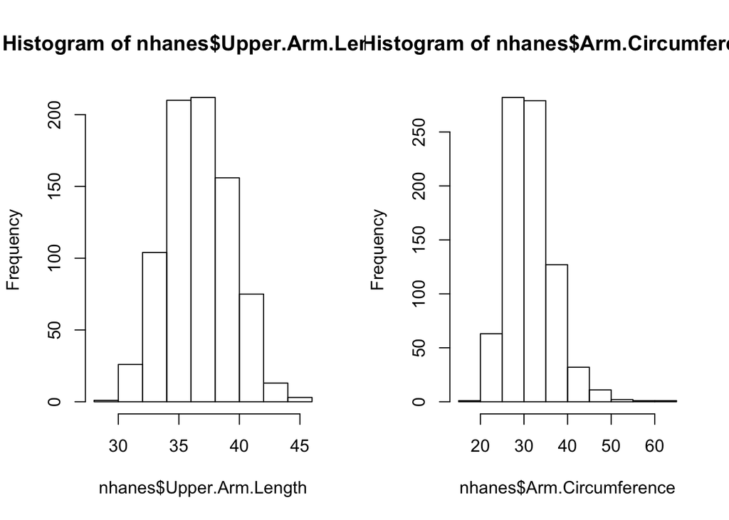

```r
par(mfrow=c(1,2))
hist(nhanes$Upper.Arm.Length)
hist(nhanes$Arm.Circumference)
```

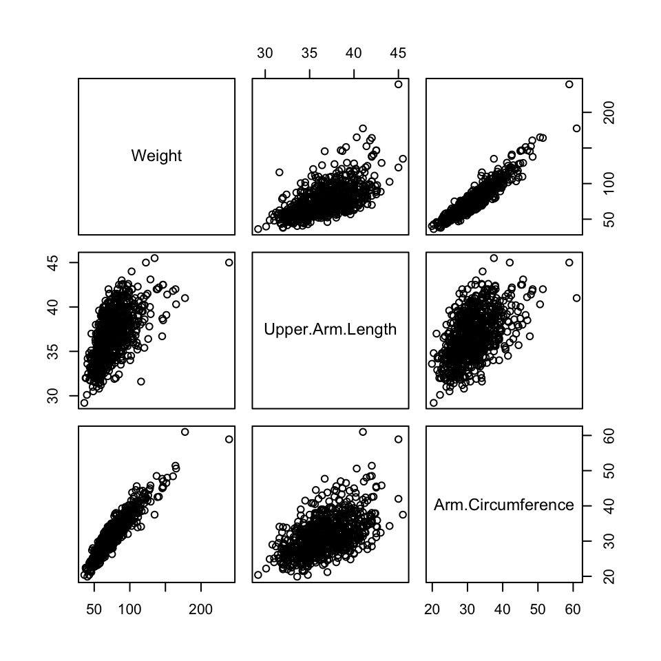

```r
pairs(~Weight+Upper.Arm.Length+Arm.Circumference, data=nhanes)
```

2. For each pair of variables, describe the main features of the relationship, noting any unusual features.
- Weight with Arm.Circumference : all points are mostly compacted in a line, which we can see the linearily in the relationship
- Weight with Upper.Arm.Length: points are condense in once place, but has many outliner.

## B. Multiple Regression Model

The simplest multiple linear regression model with two independent variables is:

$Y = \beta_0 + \beta_1 X_1 + \beta_2 X_2 + \epsilon$, where $\epsilon_i$ are independent $N(0, \sigma_{\epsilon})$.

1. In general, what would the graph of this function look like? (Hint: In 3 dimensions!)
- This graph presents in a three dimension plane.
2. How many unknown parameters are in this model? (Note that these parameters are the ones that will be estimated by the least-squares method.)
- There are three unknow parameters in this model.
3. The formulas for the least-squares estimates are similar, but more extensive, than those for the simple linear regression. Of course, we will use R to calculate these estimates for us, using our old friend `lm()`. The only change is we now indicate more than one predictor variable with a “+” sign in the formula argument:

```r
arm.lm <- lm(Weight~Arm.Circumference+Upper.Arm.Length, data=nhanes)
summary(arm.lm)
```

```
##
## Call:
## lm(formula = Weight ~ Arm.Circumference + Upper.Arm.Length, data = nhanes)
##
## Residuals:
##     Min      1Q  Median      3Q     Max
## -16.424  -4.461  -0.142   3.819  59.615
##
## Coefficients:
##                    Estimate Std. Error t value Pr(>|t|)
## (Intercept)       -80.06449    3.43732  -23.29   <2e-16 ***
## Arm.Circumference   3.42556    0.05551   61.71   <2e-16 ***
## Upper.Arm.Length    1.29076    0.10908   11.83   <2e-16 ***
## ---
## Signif. codes:  0 '***' 0.001 '**' 0.01 '*' 0.05 '.' 0.1 ' ' 1
##
## Residual standard error: 6.996 on 795 degrees of freedom
##   (5 observations deleted due to missingness)
## Multiple R-squared:  0.8915, Adjusted R-squared:  0.8912
## F-statistic:  3265 on 2 and 795 DF,  p-value: < 2.2e-16
```

## C. Diagnostics and Residual Analysis

Use the usual `plot(model)` to investigate the residual plots.

1. Verify the validity of the model assumptions using the residual plots.

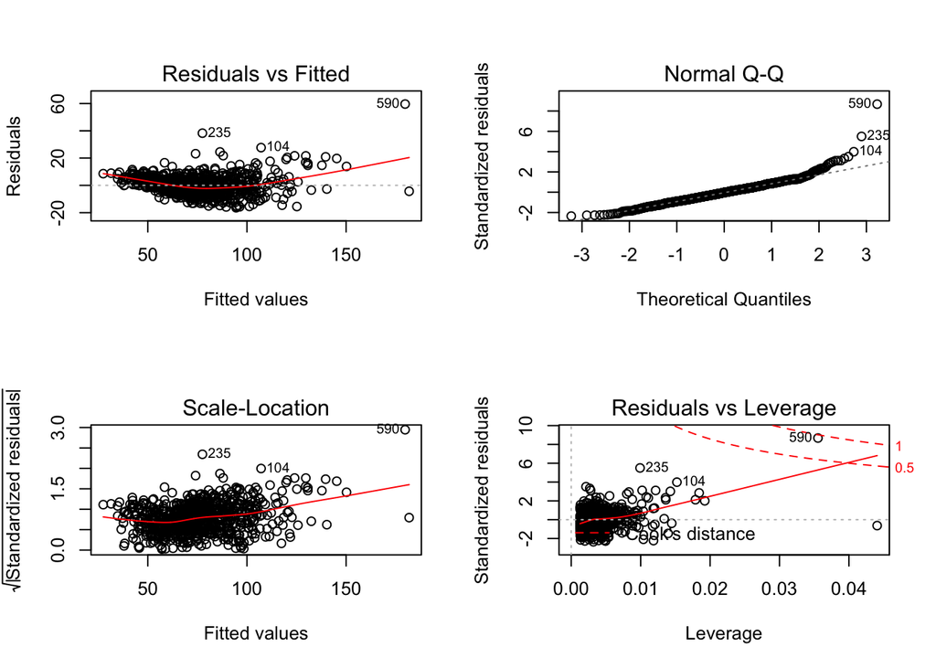

```r
par(mfrow=c(2,2))
plot(arm.lm)
```

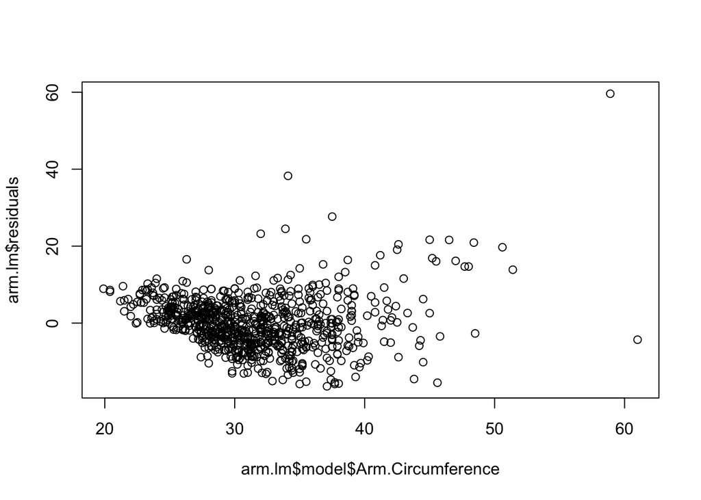

```r
plot (arm.lm$residuals ~ arm.lm$model$Arm.Circumference)
```

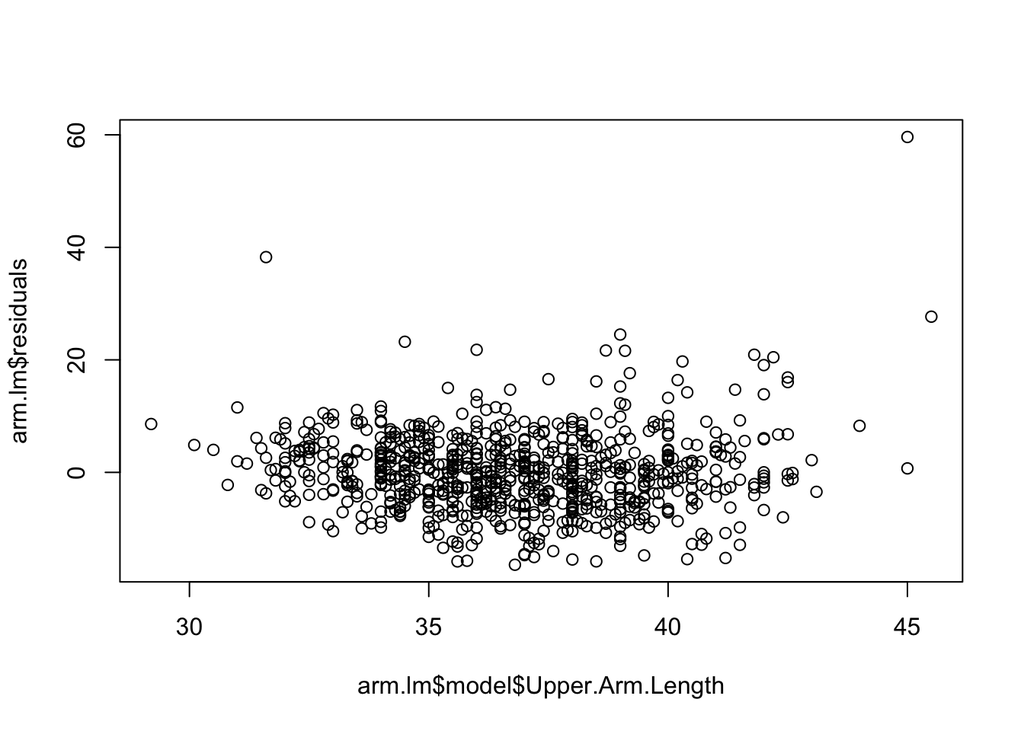

```r
plot (arm.lm$residuals ~ arm.lm$model$Upper.Arm.Length)
```

- According to graph above, the residuals vs the upper arm length values distributed constantly along the x-axis.
- The residuals vs the arm.circumference looks too bunchy and compact.
3. Carry out any “fixes” you feel are necessary (but don’t add any new terms to the model yet!) and re-run the multiple linear regression model. Verify the validity of the new model using residual plots. Did you fix the problem(s) to your satisfaction?
- Maybe we should take the log(Weight) to expand the y-axis (weight).

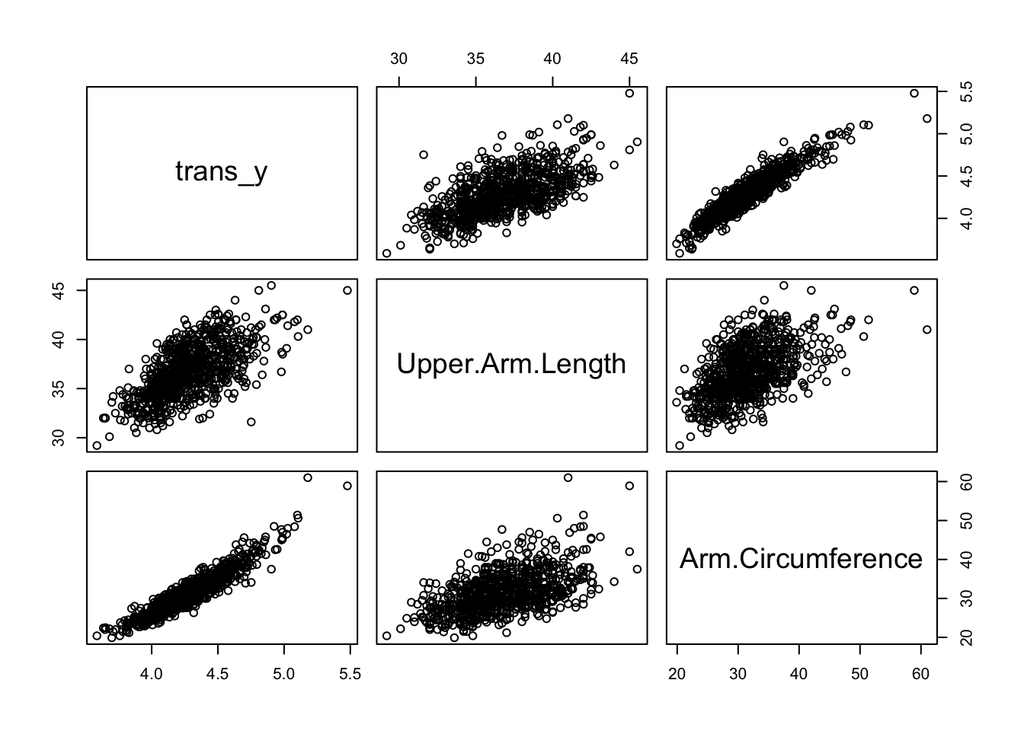

```r
nhanes$trans_y = log(nhanes$Weight)
pairs(~trans_y+Upper.Arm.Length+Arm.Circumference, data=nhanes)
```

- We still can see the linear relationship between log(weight) vs arm.circumference and log(weight) vs upper.arm.length.

```r
new_arm.lm <- lm(trans_y~Arm.Circumference+Upper.Arm.Length, data=nhanes)
summary(new_arm.lm)
```

```
##
## Call:
## lm(formula = trans_y ~ Arm.Circumference + Upper.Arm.Length,
##     data = nhanes)
##
## Residuals:
##      Min       1Q   Median       3Q      Max
## -0.38314 -0.05005 -0.00391  0.05001  0.46421
##
## Coefficients:
##                   Estimate Std. Error t value Pr(>|t|)
## (Intercept)       2.274789   0.038513   59.06   <2e-16 ***
## Arm.Circumference 0.040324   0.000622   64.83   <2e-16 ***
## Upper.Arm.Length  0.020184   0.001222   16.51   <2e-16 ***
## ---
## Signif. codes:  0 '***' 0.001 '**' 0.01 '*' 0.05 '.' 0.1 ' ' 1
##
## Residual standard error: 0.07839 on 795 degrees of freedom
##   (5 observations deleted due to missingness)
## Multiple R-squared:  0.9071, Adjusted R-squared:  0.9068
## F-statistic:  3879 on 2 and 795 DF,  p-value: < 2.2e-16
```

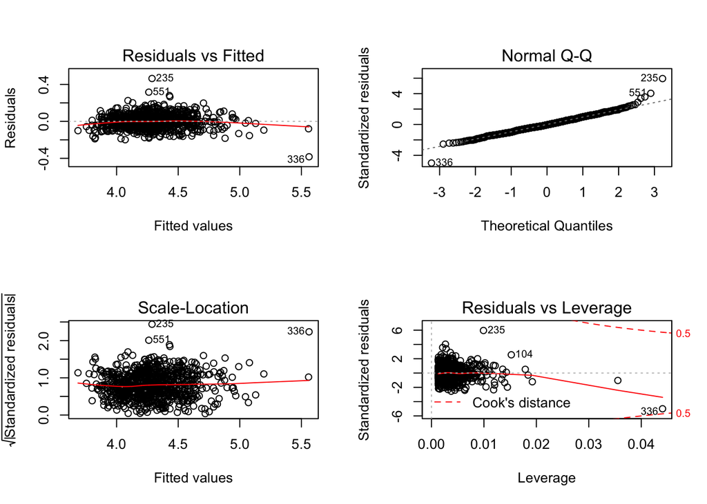

```r
par(mfrow=c(2,2))
plot(new_arm.lm)
```

- Normal Q-Q: Normal distribution
- Residuals vs fitted values: Looks good with constant variance
- The new model has p-value ~ 0, which means this model is useful. Similarity, arm.circumference and upper.arm.length do have a linear relationship with the log(Weight).

## D. Inferences About $\beta$ Parameters

```r
confint(arm.lm, level = 0.95)
```

```
##                        2.5 %     97.5 %
## (Intercept)       -86.811790 -73.317183
## Arm.Circumference   3.316596   3.534532
## Upper.Arm.Length    1.076633   1.504888
```

```r
anova(arm.lm)
```

```
## Analysis of Variance Table
##
## Response: Weight
##                    Df Sum Sq Mean Sq F value    Pr(>F)
## Arm.Circumference   1 312829  312829 6390.90 < 2.2e-16 ***
## Upper.Arm.Length    1   6853    6853  140.01 < 2.2e-16 ***
## Residuals         795  38915      49
## ---
## Signif. codes:  0 '***' 0.001 '**' 0.01 '*' 0.05 '.' 0.1 ' ' 1
```

- F-statstic: 3265 on 2 and 795 DF
- In particular, we are testing correlation = 0 (the Null) and correlation 0 (not the null). p-value < 2.2e-16 ~ 0, which means upper.arm.length and arm.circumference is useful in predicting weight.
5. Interpret $R^2$ in context.
- $R^2$ = 0.8915
- 90 Percent of variablity of weight is explained by this model.